# Correlation and Linear Regression Workshop

Jeremy Mathews

January 17, 2020

This workshop is designed to compliment the Correlations and Linear Regression Lecture from the BICF Data Science in R Nanocourse.

Try to answer the following questions to the best of your ability. If you need further assistance please raise your hand and an instructor or T.A. will come by and help you.

## Problem 1

Lets consider the swiss dataset. This dataset contains data on Swiss fertility and socioeconomic indicators from 1888. Specifically, lets take a look at Fertility and Infant Mortality.

```r
swiss
```

```
##              Fertility Agriculture Examination Education Catholic
## Courtelary        80.2        17.0          15        12     9.96
## Delemont          83.1        45.1           6         9    84.84
## Franches-Mnt      92.5        39.7           5         5    93.40
## Moutier           85.8        36.5          12         7    33.77
## Neuveville        76.9        43.5          17        15     5.16
## Porrentruy        76.1        35.3           9         7    90.57
## Broye             83.8        70.2          16         7    92.85
## Glane             92.4        67.8          14         8    97.16
## Gruyere           82.4        53.3          12         7    97.67
## Sarine            82.9        45.2          16        13    91.38
## Veveyse           87.1        64.5          14         6    98.61
## Aigle             64.1        62.0          21        12     8.52
## Aubonne           66.9        67.5          14         7     2.27
## Avenches          68.9        60.7          19        12     4.43
## Cossonay          61.7        69.3          22         5     2.82
## Echallens         68.3        72.6          18         2    24.20
## Grandson          71.7        34.0          17         8     3.30
## Lausanne          55.7        19.4          26        28    12.11
## La Vallee         54.3        15.2          31        20     2.15
## Lavaux            65.1        73.0          19         9     2.84
## Morges            65.5        59.8          22        10     5.23
## Moudon            65.0        55.1          14         3     4.52
## Nyone             56.6        50.9          22        12    15.14
## Orbe              57.4        54.1          20         6     4.20
## Oron              72.5        71.2          12         1     2.40
## Payerne           74.2        58.1          14         8     5.23
## Paysd'enhaut      72.0        63.5           6         3     2.56
## Rolle             60.5        60.8          16        10     7.72
## Vevey             58.3        26.8          25        19    18.46
## Yverdon           65.4        49.5          15         8     6.10
## Conthey           75.5        85.9           3         2    99.71
## Entremont         69.3        84.9           7         6    99.68
## Herens            77.3        89.7           5         2   100.00
## Martigwy          70.5        78.2          12         6    98.96
## Monthey           79.4        64.9           7         3    98.22
## St Maurice        65.0        75.9           9         9    99.06
## Sierre            92.2        84.6           3         3    99.46
## Sion              79.3        63.1          13        13    96.83
## Boudry            70.4        38.4          26        12     5.62
```

[output cut: 41 more lines]

```
## Herens                   18.3
## Martigwy                 19.4
## Monthey                  20.2
## St Maurice               17.8
## Sierre                   16.3
## Sion                     18.1
## Boudry                   20.3
## La Chauxdfnd             20.5
## Le Locle                 18.9
## Neuchatel                23.0
## Val de Ruz               20.0
## ValdeTravers             19.5
## V. De Geneve             18.0
## Rive Droite              18.2
## Rive Gauche              19.3
```

1. Pick an alpha value and generate a hypothesis as to linear association between fertility and infant mortality.

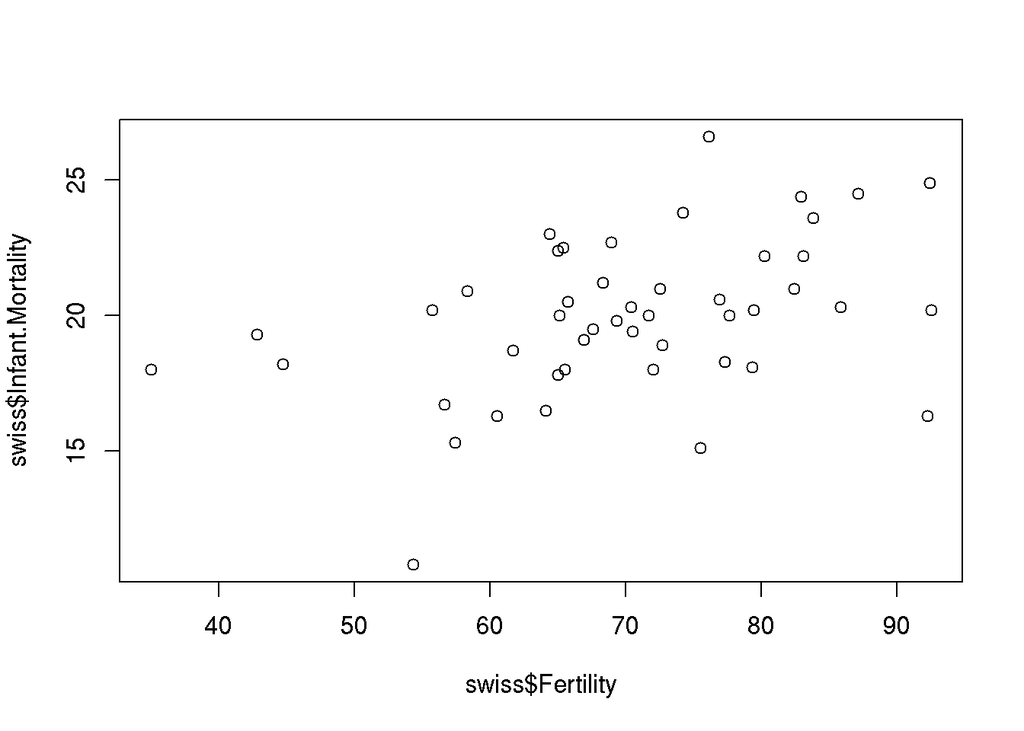

```r
plot(swiss$Fertility, swiss$Infant.Mortality)
```

H0: $\rho$ = 0  
H1: $\rho$ > 0

$\alpha$ = 0.05

2. Test the correlation between these two variables.

```r
cor.test(swiss$Fertility, swiss$Infant.Mortality, "greater")
```

```
##
##  Pearson's product-moment correlation
##
## data:  swiss$Fertility and swiss$Infant.Mortality
## t = 3.0737, df = 45, p-value = 0.001793
## alternative hypothesis: true correlation is greater than 0
## 95 percent confidence interval:
##  0.1930918 1.0000000
## sample estimates:
##      cor
## 0.416556
```

3. Draw a conclusion as to the linear association between fertility and infant mortality.  
   The Pearson correlation test returned a p-value of 0.001793, which is less than 0.05. So, there is enough statistical significance to reject the null hypothesis. The data appears to have a linear association between fertility and infant mortality. The correlation coefficient is 0.416556, which does not show a very strong linear association, but does show that the relationship is positive.
4. Generate a linear regression model to estimate the relationship between fertility and infant mortality.

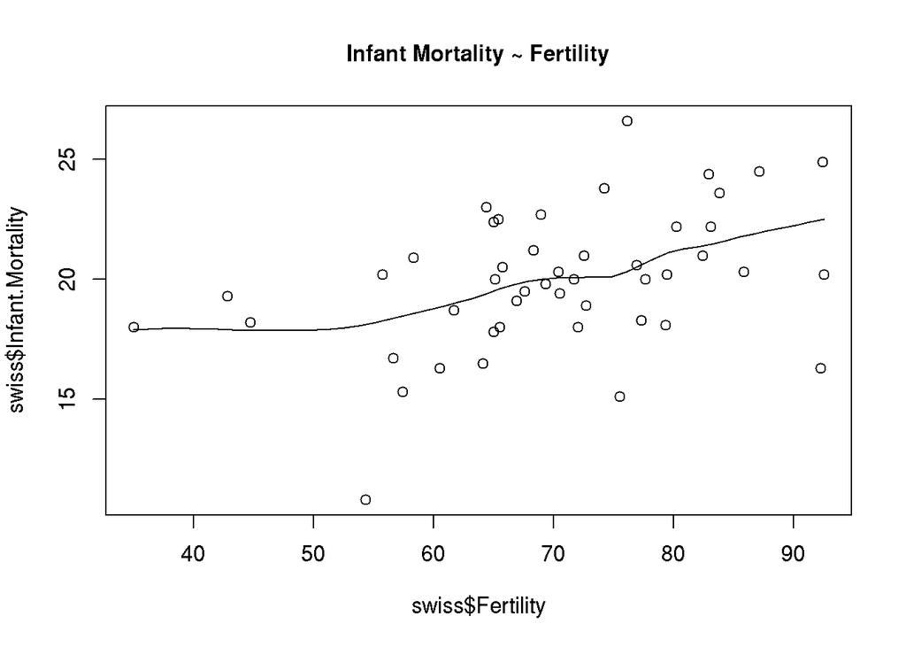

```r
scatter.smooth(x=swiss$Fertility, y=swiss$Infant.Mortality, main="Infant Mortality ~ Fertility")
```

```r
lr <- lm(Infant.Mortality ~ Fertility, data=swiss)
lr
```

```
##
## Call:
## lm(formula = Infant.Mortality ~ Fertility, data = swiss)
##
## Coefficients:
## (Intercept)    Fertility
##    13.12970      0.09713
```

```r
summary(lr)
```

```
##
## Call:
## lm(formula = Infant.Mortality ~ Fertility, data = swiss)
##
## Residuals:
##     Min      1Q  Median      3Q     Max
## -7.6038 -1.5673 -0.0607  1.8367  6.0788
##
## Coefficients:
##             Estimate Std. Error t value Pr(>|t|)
## (Intercept) 13.12970    2.25063   5.834 5.51e-07 ***
## Fertility    0.09713    0.03160   3.074  0.00359 **
## ---
## Signif. codes:  0 '***' 0.001 '**' 0.01 '*' 0.05 '.' 0.1 ' ' 1
##
## Residual standard error: 2.677 on 45 degrees of freedom
## Multiple R-squared:  0.1735, Adjusted R-squared:  0.1552
## F-statistic: 9.448 on 1 and 45 DF,  p-value: 0.003585
```

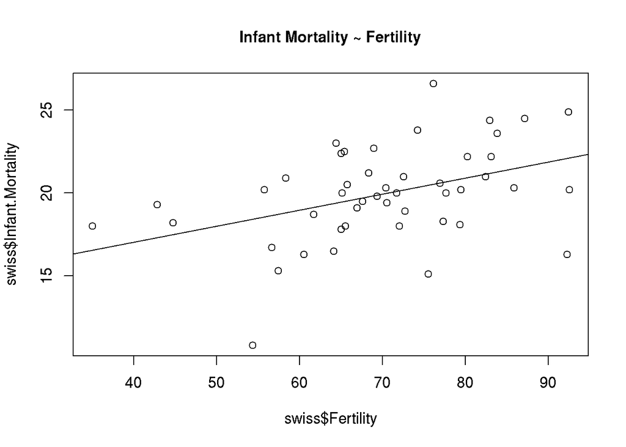

```r
plot(swiss$Fertility, swiss$Infant.Mortality, main="Infant Mortality ~ Fertility")
abline(lr)
```

The linear regression model returned a p-value of 0.003585 which is less than 0.05. So, there is enough statistical significance to reject the null hypothesis. This means that there appears to be a linear model that describes the relationship in the data with the equation $y = 0.09713x + 13.12970$. It is important to note however that only 15.52 percent of the variation in the data is explained by this model.

## Problem 2

Lets consider the pressure dataset. This dataset contains data on the temperature and vapor pressure of mercury. We would like to know if there is a correlation between the temperature and pressure.

```r
pressure
```

```
##    temperature pressure
## 1            0   0.0002
## 2           20   0.0012
## 3           40   0.0060
## 4           60   0.0300
## 5           80   0.0900
## 6          100   0.2700
## 7          120   0.7500
## 8          140   1.8500
## 9          160   4.2000
## 10         180   8.8000
## 11         200  17.3000
## 12         220  32.1000
## 13         240  57.0000
## 14         260  96.0000
## 15         280 157.0000
## 16         300 247.0000
## 17         320 376.0000
## 18         340 558.0000
## 19         360 806.0000
```

1. Which correlation test can be performed and why?

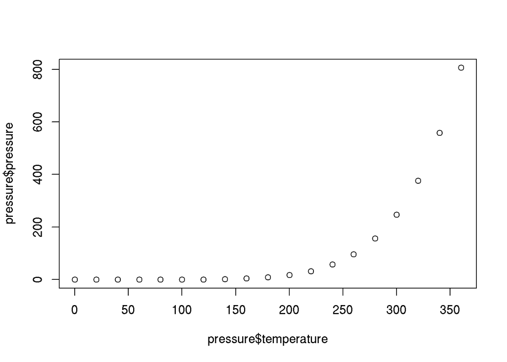

```r
plot(pressure$temperature, pressure$pressure)
```

Notice that the graph of the data is not linear, so a Pearson correlation would not be appropriate in this case. The data however does appear to be monotonically increasing. So we can use a spearman correlation.

2. Do the test and interpret the results.

```r
cor(pressure$temperature, pressure$pressure, method = "spearman")
```

```
## [1] 1
```

The results of the test show a spearman correlation coefficient of 1. This means that there is a very strong, positive correlation in the data. (Almost too perfect)

3. **Bonus** Why does the results show what they do?

While normally, this would not be accurate, because 1 is a perfect correlation and should raise serious concerns. If we look at the graph of data then it would appear as though the correlation is close to perfect. **This is one of the reasons mercury is used in thermometers.**